# Reproducible Research: Peer Assessment 1

## Loading and preprocessing the data

library(plyr)

library(lubridate)

library(knitr)

1. Load the data
2. Process/transform the data (if necessary) into a format suitable for your analysis

```r
activity <- read.csv("H:/Data Sci JHU/data/activity.csv")
```

## What is mean total number of steps taken per day?

– Ignore the missing values for now

1. Calcualte the total number of steps taken per day.

```r
stepsperday <- tapply(activity$steps, activity$date, function(x) sum(x, na.rm=TRUE))
```

2. Make a histogram of the total number of steps taken each day.

Fig 1

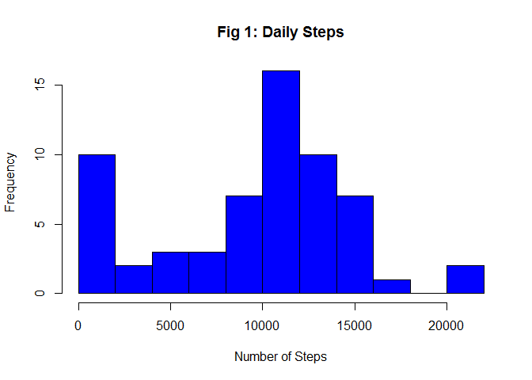

```r
hist(stepsperday,
      breaks=15,
      col="blue",
      xlab="Number of Steps",
      main="Fig 1: Daily Steps")
```

3. Calculate and report the mean and median of the total number of steps taken per day.

```r
stepsmean <- mean(stepsperday, na.rm=TRUE)

stepsmean
```

```
## [1] 9354.23
```

```r
stepsmedian <- median(stepsperday, na.rm=TRUE)

stepsmedian
```

```
## [1] 10395
```

## What is the average daily activity pattern?

1. Make a time series plot (ie type=“l”) of the 5-min intervals (x-axis) and the average number of steps taken, averaged across all days (y-axis).

Fig 2

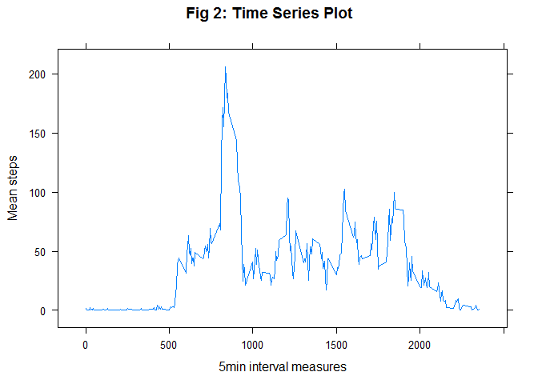

```r
library(lattice)

steptimeplot <- aggregate(activity$steps ~ activity$interval, activity, FUN=mean, na.rm=TRUE)

names(steptimeplot) <- c("interval", "mean_steps")

xyplot(steptimeplot$mean_steps ~ steptimeplot$interval,
          type="l",
          ylab="Mean steps",
          xlab="5min interval measures",
          main="Fig 2: Time Series Plot")
```

2. Which 5-min interval, on average across all the days in the dataset, contains the max number of steps?

```r
maxsteps <- which.max(steptimeplot$mean_steps)

maxsteps
```

```
## [1] 104
```

## Imputing missing values

– Missing values coded as NA

1. Calculate and report the total number of missing values in the dataset (ie the total number of rows with NAs).

```r
sum(is.na(activity$steps))
```

```
## [1] 2304
```

2. Devise a strategy for filling in all of the missing values in the dataset.

```r
sub_na <- activity[is.na(activity),]
sub_na$steps <- merge(steptimeplot, sub_na)$mean_steps
```

3. Create a new dataset that is equal to the original dataset but with the missing data filled in.

```r
filledactivity <- activity
filledactivity[is.na(activity),] <- sub_na
dailystepsfilled <- tapply(filledactivity$steps, filledactivity$date, function(x) mean(x))
```

Fig 3

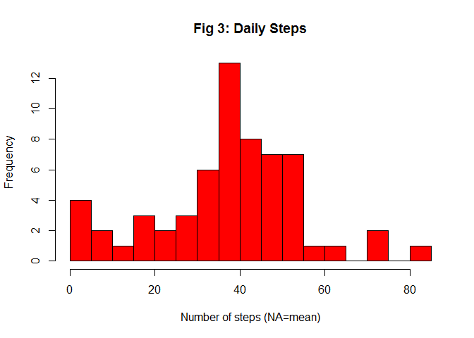

```r
hist(dailystepsfilled,
      breaks=15,
      col="red",
      xlab="Number of steps (NA=mean)",
      main="Fig 3: Daily Steps")
```

## Are there differences in activity patterns between weekdays and weekends?

– Use the filled in dataset

1. Create a new factor variable in the dataset with two levels- “weekday” and “weekend”

```r
daytype <- function(date) {
            if (weekdays(as.Date(date)) %in% c("Saturday", "Sunday"))  {
                      "Weekend"
            } else {
                      "Weekday"
            }
}

filledactivity$daytype <- as.factor(sapply(filledactivity$date, daytype))
filledactivity$day <- sapply(filledactivity$date, FUN=daytype)
```

2. Make a panel plot containing a time series plot (ie type=“l”) of the 5-min interval (x-axis) and the average number of steps taken, averages across all weekdays or weekend days (y-axis).

Fig 4

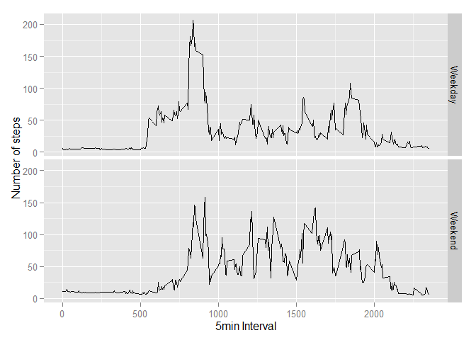

```r
library(ggplot2)

averages <- aggregate(steps ~ interval+day, data=filledactivity, mean)

ggplot(averages, aes(interval, steps)) + geom_line() + facet_grid(day ~ .) + xlab("5min Interval") + ylab("Number of steps")
```